```python
# Computations
import pandas as pd
import numpy as np

# sklearn
from sklearn.metrics import classification_report, accuracy_score, f1_score, precision_score, recall_score
from sklearn.metrics import plot_confusion_matrix
from sklearn.preprocessing import StandardScaler
from sklearn.model_selection import train_test_split, GridSearchCV, RandomizedSearchCV, cross_val_score, KFold
from sklearn.feature_selection import RFE
from sklearn.tree import DecisionTreeClassifier
from sklearn.ensemble import RandomForestClassifier
from sklearn import metrics

# preprocessing
from sklearn.preprocessing import StandardScaler
from sklearn.impute import SimpleImputer

# Text
from colorama import Fore, Back, Style
import re

# Visualisation libraries
import seaborn as sns
import matplotlib.pyplot as plt
from plotly.offline import init_notebook_mode, iplot
import plotly.graph_objs as go

# Graphics in retina format
%config InlineBackend.figure_format = 'retina'

# sns setting
sns.set_context("paper", rc={"font.size":12,"axes.titlesize":14,"axes.labelsize":12})
sns.set_style("whitegrid")

# plt setting
plt.style.use('seaborn-whitegrid')
plt.rcParams['axes.labelsize'] = 14
plt.rcParams['xtick.labelsize'] = 12
plt.rcParams['ytick.labelsize'] = 12
plt.rcParams['text.color'] = 'k'
%matplotlib inline
import warnings
warnings.filterwarnings("ignore")
```

# Daily Weather Data Analysis and Classification

In this article, we analyze a weather dataset from [**Kaggle.com**](https://www.kaggle.com/ashukr/weatherdata). Data description from Kaggle:

- Sensor measurements from the weather station were captured at one-minute intervals. These measurements were then processed to generate values to describe daily weather. Since this dataset was created to classify
- low-humidity days vs. non-low-humidity days (that is, days with normal or high humidity), the variables included are weather measurements in the morning, with one measurement, nAMely relatively humidity, in the afternoon. The idea is to use the morning weather values to predict whether the day will be low-humidity or not based on the afternoon measurement of relative humidity.
- Each row, or sAMple, consists of the following variables:
  - Number: unique number for each row
  - air_pressure_9am: air pressure averaged over a period from 8:55 AM to 9:04 AM (Unit: hectopascals)
  - air_temp_9am: air temperature averaged over a period from 8:55 AM to 9:04 AM (Unit: degrees Fahrenheit)
- air_wind_direction_9am: wind direction averaged over a period from 8:55AM to 9:04AM (Unit: degrees,
  - with 0 means coming from the North, and increasing clockwise)
- air_wind_speed_9am: wind speed averaged over a period from 8:55AM to 9:04AM (Unit: miles per hour) max_wind_direction_9am: wind gust direction averaged over a period from 8:55AM to 9:10AM (Unit:
  - degrees, with 0 being North and increasing clockwise)
- max_wind_speed_9am: wind gust speed averaged over a period from 8:55 AM to 9:04 AM (Unit: miles per hour)
- rain_accumulation_9am: the AMount of rain accumulated in the 24 hours before 9 AM (Unit: millimeters)
- rain_duration_9am: the AMount of time rain was recorded in the 24 hours before 9 AM (Unit: seconds)
- relative_humidity_9am: relative humidity averaged over a period from 8:55 AM to 9:04 AM (Unit: percent)
- relative_humidity_3pm: relative humidity averaged over a period from 2:55 PM to 3:04 PM (Unit: percent )
- The Dataset
- Preprocessing
- Problem Description
- Modeling
  - Decision Tree Classifier
  - Random Forest Classifier
- Final Thoughts

## The Dataset

### Loading the Dataset

```python
Data = pd.read_csv('weatherdata/daily_weather.csv')
Data.drop(columns = ['number'], inplace = True)
Data.head().style.hide_index().set_precision(2)
```

| air_pressure_9am | air_temp_9am | avg_wind_direction_9am | avg_wind_speed_9am | max_wind_direction_9am | max_wind_speed_9am | rain_accumulation_9am | rain_duration_9am | relative_humidity_9am | relative_humidity_3pm |
| --- | --- | --- | --- | --- | --- | --- | --- | --- | --- |
| 918.06 | 74.82 | 271.10 | 2.08 | 295.40 | 2.86 | 0.00 | 0.00 | 42.42 | 36.16 |
| 917.35 | 71.40 | 101.94 | 2.44 | 140.47 | 3.53 | 0.00 | 0.00 | 24.33 | 19.43 |
| 923.04 | 60.64 | 51.00 | 17.07 | 63.70 | 22.10 | 0.00 | 20.00 | 8.90 | 14.46 |
| 920.50 | 70.14 | 198.83 | 4.34 | 211.20 | 5.19 | 0.00 | 0.00 | 12.19 | 12.74 |
| 921.16 | 44.29 | 277.80 | 1.86 | 136.50 | 2.86 | 8.90 | 14730.00 | 92.41 | 76.74 |

### Features

[output not shown]

For convenience, we would like to modify the feature names.

```python
Data.columns = [x.replace('ty_9am','ty_(Morning)').replace('3pm', '(Afternoon)').replace('_9am', '').replace('_',
                                                      ' ').title().replace('Temp','Temperature') for x in Data.columns.tolist()]
Data.head(5).style.hide_index().set_precision(2)
```

| Air Pressure | Air Temperature | Avg Wind Direction | Avg Wind Speed | Max Wind Direction | Max Wind Speed | Rain Accumulation | Rain Duration | Relative Humidity (Morning) | Relative Humidity (Afternoon) |
| --- | --- | --- | --- | --- | --- | --- | --- | --- | --- |
| 918.06 | 74.82 | 271.10 | 2.08 | 295.40 | 2.86 | 0.00 | 0.00 | 42.42 | 36.16 |
| 917.35 | 71.40 | 101.94 | 2.44 | 140.47 | 3.53 | 0.00 | 0.00 | 24.33 | 19.43 |
| 923.04 | 60.64 | 51.00 | 17.07 | 63.70 | 22.10 | 0.00 | 20.00 | 8.90 | 14.46 |
| 920.50 | 70.14 | 198.83 | 4.34 | 211.20 | 5.19 | 0.00 | 0.00 | 12.19 | 12.74 |
| 921.16 | 44.29 | 277.80 | 1.86 | 136.50 | 2.86 | 8.90 | 14730.00 | 92.41 | 76.74 |

# Preprocessing

## Imputing Missing Values

Note that

```python
def Data_info(Inp, Only_NaN = False):
    Out = Inp.dtypes.to_frame(name='Data Type').sort_values(by=['Data Type'])
    Out = Out.join(Inp.isnull().sum().to_frame(name = 'Number of NaN Values'), how='outer')
    Out['Percentage'] = np.round(100*(Out['Number of NaN Values']/Inp.shape[0]),2)
    if Only_NaN:
        Out = Out.loc[Out['Number of NaN Values']>0]
    return Out

Temp = Data_info(Data, Only_NaN = True)
display(Temp)
Temp = Temp.index.tolist()
```

|  | Data Type | Number of NaN Values | Percentage |
| --- | --- | --- | --- |
| Air Pressure | float64 | 3 | 0.27 |
| Air Temperature | float64 | 5 | 0.46 |
| Avg Wind Direction | float64 | 4 | 0.37 |
| Avg Wind Speed | float64 | 3 | 0.27 |
| Max Wind Direction | float64 | 3 | 0.27 |
| Max Wind Speed | float64 | 4 | 0.37 |
| Rain Accumulation | float64 | 6 | 0.55 |
| Rain Duration | float64 | 3 | 0.27 |

```python
imp = SimpleImputer(missing_values=np.nan, strategy='mean')
Data[Temp] = imp.fit_transform(Data[Temp])
Data_info(Data)
```

|  | Data Type | Number of NaN Values | Percentage |
| --- | --- | --- | --- |
| Air Pressure | float64 | 0 | 0.0 |
| Air Temperature | float64 | 0 | 0.0 |
| Avg Wind Direction | float64 | 0 | 0.0 |
| Avg Wind Speed | float64 | 0 | 0.0 |
| Max Wind Direction | float64 | 0 | 0.0 |
| Max Wind Speed | float64 | 0 | 0.0 |
| Rain Accumulation | float64 | 0 | 0.0 |
| Rain Duration | float64 | 0 | 0.0 |
| Relative Humidity (Morning) | float64 | 0 | 0.0 |
| Relative Humidity (Afternoon) | float64 | 0 | 0.0 |

# Problem Description

```python
Median = Data['Relative Humidity (Afternoon)'].median()
Temp = Data['Relative Humidity (Afternoon)']> Median
Temp = Temp.astype(int)
Target = 'Relative Humidity (Afternoon)'
```

# Modeling

First off, let's look at the variance of our dataset features.

```python
display(Data.iloc[:,:-1].var().sort_values(ascending = False).to_frame(name= 'Variance')\
        .style.background_gradient(cmap='OrRd').set_precision(2))
```

|  | Variance |
| --- | --- |
| Rain Duration | 2546852.52 |
| Avg Wind Direction | 4762.57 |
| Max Wind Direction | 4508.55 |
| Relative Humidity (Morning) | 648.83 |
| Air Temperature | 124.32 |
| Max Wind Speed | 31.23 |
| Avg Wind Speed | 20.67 |
| Air Pressure | 10.11 |
| Rain Accumulation | 2.53 |

Furthermore, we would like to standardize features by removing the mean and scaling to unit **variance**. In this [article](https://hatefdastour.github.io/portfolio/statistical_modeling/Pima_Indians_Diabetes_Data_Classification.html), we demonstrated the benefits of scaling data using [**StandardScaler()**](https://scikit-learn.org/stable/modules/generated/sklearn.preprocessing.StandardScaler.html).

```python
df = Data.copy()
df['Relative Humidity (Afternoon)'] = Temp
scaler = StandardScaler()
df.iloc[:,:-1] = scaler.fit_transform(df.iloc[:,:-1])

display(df.iloc[:,:-1].var().sort_values(ascending = False).to_frame(name= 'Variance')\
       .style.background_gradient(cmap=sns.light_palette("green", as_cmap=True)).set_precision(2))
```

|  | Variance |
| --- | --- |
| Rain Duration | 1.00 |
| Air Temperature | 1.00 |
| Avg Wind Speed | 1.00 |
| Max Wind Speed | 1.00 |
| Max Wind Direction | 1.00 |
| Avg Wind Direction | 1.00 |
| Relative Humidity (Morning) | 1.00 |
| Air Pressure | 1.00 |
| Rain Accumulation | 1.00 |

```python
df.describe().style.set_precision(2)
```

|  | Air Pressure | Air Temperature | Avg Wind Direction | Avg Wind Speed | Max Wind Direction | Max Wind Speed | Rain Accumulation | Rain Duration | Relative Humidity (Morning) | Relative Humidity (Afternoon) |
| --- | --- | --- | --- | --- | --- | --- | --- | --- | --- | --- |
| count | 1095.00 | 1095.00 | 1095.00 | 1095.00 | 1095.00 | 1095.00 | 1095.00 | 1095.00 | 1095.00 | 1095.00 |
| mean | 0.00 | -0.00 | -0.00 | -0.00 | 0.00 | -0.00 | 0.00 | -0.00 | 0.00 | 0.50 |
| std | 1.00 | 1.00 | 1.00 | 1.00 | 1.00 | 1.00 | 1.00 | 1.00 | 1.00 | 0.50 |
| min | -3.43 | -2.53 | -1.84 | -1.06 | -1.79 | -1.04 | -0.13 | -0.18 | -1.11 | 0.00 |
| 25% | -0.73 | -0.68 | -1.10 | -0.72 | -1.08 | -0.71 | -0.13 | -0.18 | -0.75 | 0.00 |
| 50% | 0.01 | 0.07 | 0.34 | -0.36 | 0.42 | -0.37 | -0.13 | -0.18 | -0.43 | 0.00 |
| 75% | 0.72 | 0.76 | 0.71 | 0.40 | 0.78 | 0.33 | -0.13 | -0.18 | 0.44 | 1.00 |
| max | 3.28 | 3.05 | 2.92 | 3.97 | 2.43 | 4.09 | 14.99 | 10.91 | 2.29 | 1.00 |

```python
X = df.drop(columns = [Target])
y = df[Target]
X_train, X_test, y_train, y_test = train_test_split(X, y, test_size=0.3, random_state=42)
pd.DataFrame(data={'Set':['X_train','X_test','y_train','y_test'],
               'Shape':[X_train.shape, X_test.shape, y_train.shape, y_test.shape]}).set_index('Set').T
```

| Set | X_train | X_test | y_train | y_test |
| --- | --- | --- | --- | --- |
| Shape | (766, 9) | (329, 9) | (766,) | (329,) |

A number of functions that we would use.

```python
def Performance(clf, X_test):
    df = pd.DataFrame()
    y_pred = clf.predict(X_test)
    df = df.append({'Classifier': re.sub(r"(\w)([A-Z])", r"\1 \2",re.findall('[^()]+', str(clf))[0]),
                    'Score': clf.score(X_test, y_test),
                    'F1 Score': f1_score(y_test.values, y_pred, average= 'weighted'),
                    'Precision Score': precision_score(y_test.values, y_pred, average= 'weighted'),
                    'Recall Score':  recall_score(y_test.values, y_pred, average= 'weighted')}, ignore_index=True)
    display(df.style.hide_index().set_precision(2))
    return df

def highlight_max(s):
    is_max = s == s.max()
    return ['background-color: SpringGreen' if v else '' for v in is_max]


def Feature_Ranking(clf):
    df = pd.DataFrame()
    for n in range(2, X.shape[1]):
        selector = RFE(estimator= clf, n_features_to_select=n, verbose=0)
        selector.fit(X_train, y_train)
        df = df.append({'Number of Features to Select': n,
                        'Score':metrics.accuracy_score(y_test, selector.predict(X_test)),
                        'Features': X.columns[selector.support_].tolist(),
                        'Best Features':X.columns[selector.ranking_ == 1].tolist()}, ignore_index=True)

    df = df[['Number of Features to Select', 'Score', 'Features', 'Best Features']]
    df['Number of Features to Select'] = df['Number of Features to Select'].astype(int)
    df['Score'] = df['Score'].round(2)
    display(df.style.apply(highlight_max, subset=['Score']))
    return df.loc[df.Score == df.Score.max(), 'Features'].values[0]

def ROC_Curve(clf, X_test):
    # false positive rates, true positive rates and thresholds
    fpr, tpr, threshold = metrics.roc_curve(y_test, clf.predict_proba(X_test)[:,1])

    fig, ax = plt.subplots(1, 1, figsize=(5.5, 5.5))
    _ = ax.plot(fpr, tpr, lw=2, label = 'AUC = %0.2f' % metrics.auc(fpr, tpr))
    _ = ax.plot([0, 1], [0, 1],'r--', lw=2)
    _ = ax.legend(loc = 'lower right', fontsize = 14)
    _ = ax.set_xlim([0,1])
    # _ = ax.set_ylim([0,1])
    _ = ax.set_xlabel('False Positive Rate (FPR)')
    _ = ax.set_ylabel('True Positive Rate (TPR)')
    return pd.DataFrame({'false positive rates':fpr, 'true positive rates':tpr, 'thresholds':threshold})
```

## DecisionTreeClassifier

First, let's try [scikit-learn Decision Tree Classifier](https://scikit-learn.org/stable/modules/generated/sklearn.tree.DecisionTreeClassifier.html).

| Classifier | F1 Score | Precision Score | Recall Score | Score |
| --- | --- | --- | --- | --- |
| Decision Tree Classifier | 0.87 | 0.87 | 0.87 | 0.87 |

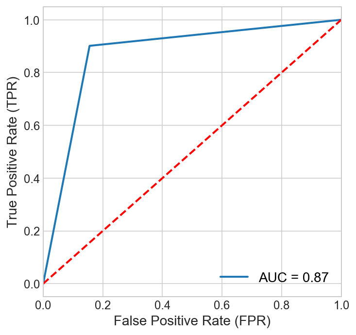

```python
dtc = DecisionTreeClassifier()
_ = dtc.fit(X_train, y_train)
Performance_dtc = Performance(dtc, X_test)
ROC_dtc = ROC_Curve(dtc, X_test)
```

```python
Best_Features_dtc = Feature_Ranking(dtc)
print(Back.BLACK + Fore.CYAN + Style.NORMAL + 'Best Features:')
print(Style.RESET_ALL)
print('%s' % ', '.join(Best_Features_dtc))
```

|  | Number of Features to Select | Score | Features | Best Features |
| --- | --- | --- | --- | --- |
| 0 | 2 | 0.820000 | ['Air Pressure', 'Relative Humidity (Morning)'] | ['Air Pressure', 'Relative Humidity (Morning)'] |
| 1 | 3 | 0.880000 | ['Air Pressure', 'Air Temperature', 'Relative Humidity (Morning)'] | ['Air Pressure', 'Air Temperature', 'Relative Humidity (Morning)'] |
| 2 | 4 | 0.860000 | ['Air Pressure', 'Air Temperature', 'Max Wind Direction', 'Relative Humidity (Morning)'] | ['Air Pressure', 'Air Temperature', 'Max Wind Direction', 'Relative Humidity (Morning)'] |
| 3 | 5 | 0.850000 | ['Air Pressure', 'Air Temperature', 'Max Wind Direction', 'Max Wind Speed', 'Relative Humidity (Morning)'] | ['Air Pressure', 'Air Temperature', 'Max Wind Direction', 'Max Wind Speed', 'Relative Humidity (Morning)'] |
| 4 | 6 | 0.880000 | ['Air Pressure', 'Air Temperature', 'Avg Wind Direction', 'Max Wind Direction', 'Max Wind Speed', 'Relative Humidity (Morning)'] | ['Air Pressure', 'Air Temperature', 'Avg Wind Direction', 'Max Wind Direction', 'Max Wind Speed', 'Relative Humidity (Morning)'] |
| 5 | 7 | 0.880000 | ['Air Pressure', 'Air Temperature', 'Avg Wind Direction', 'Avg Wind Speed', 'Max Wind Direction', 'Max Wind Speed', 'Relative Humidity (Morning)'] | ['Air Pressure', 'Air Temperature', 'Avg Wind Direction', 'Avg Wind Speed', 'Max Wind Direction', 'Max Wind Speed', 'Relative Humidity (Morning)'] |
| 6 | 8 | 0.870000 | ['Air Pressure', 'Air Temperature', 'Avg Wind Direction', 'Avg Wind Speed', 'Max Wind Direction', 'Max Wind Speed', 'Rain Accumulation', 'Relative Humidity (Morning)'] | ['Air Pressure', 'Air Temperature', 'Avg Wind Direction', 'Avg Wind Speed', 'Max Wind Direction', 'Max Wind Speed', 'Rain Accumulation', 'Relative Humidity (Morning)'] |

```
Best Features:

Air Pressure, Air Temperature, Relative Humidity (Morning)
```

| Classifier | F1 Score | Precision Score | Recall Score | Score |
| --- | --- | --- | --- | --- |
| Decision Tree Classifier | 0.87 | 0.87 | 0.87 | 0.87 |

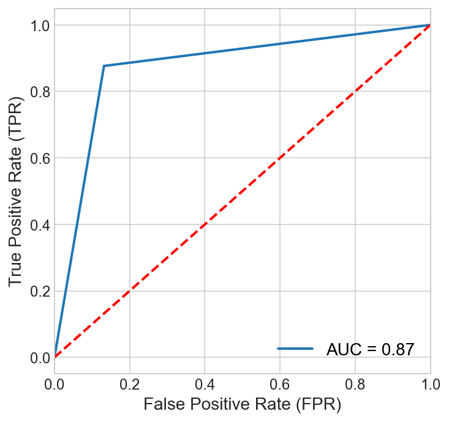

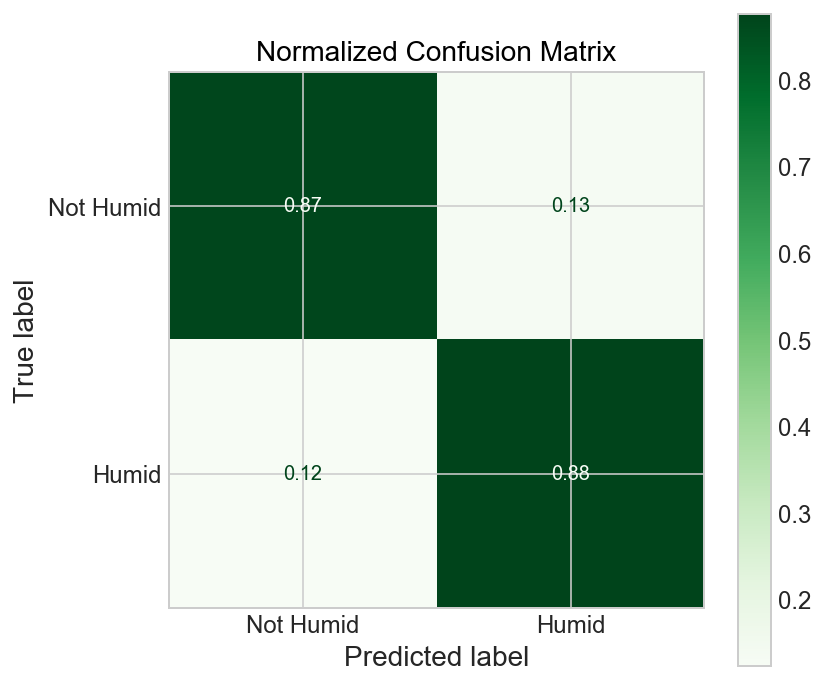

```python
dtc = DecisionTreeClassifier()
_ = dtc.fit(X_train[Best_Features_dtc], y_train)
Performance_dtc = Performance(dtc, X_test[Best_Features_dtc])
ROC_dtc = ROC_Curve(dtc, X_test[Best_Features_dtc])


fig, ax = plt.subplots(1, 1, figsize=(6, 6))
_ = plot_confusion_matrix(dtc, X_test[Best_Features_dtc], y_test, display_labels= ['Not Humid','Humid'],
                      cmap= "Greens", normalize= 'true', ax = ax)
_ = ax.set_title('Normalized Confusion Matrix')
```

## Random Forest Classifier

Next, let's use [scikit-learn Random Forest Classifier](https://scikit-learn.org/stable/modules/generated/sklearn.ensemble.RandomForestClassifier.html).

| Classifier | F1 Score | Precision Score | Recall Score | Score |
| --- | --- | --- | --- | --- |
| Random Forest Classifier | 0.93 | 0.93 | 0.93 | 0.93 |

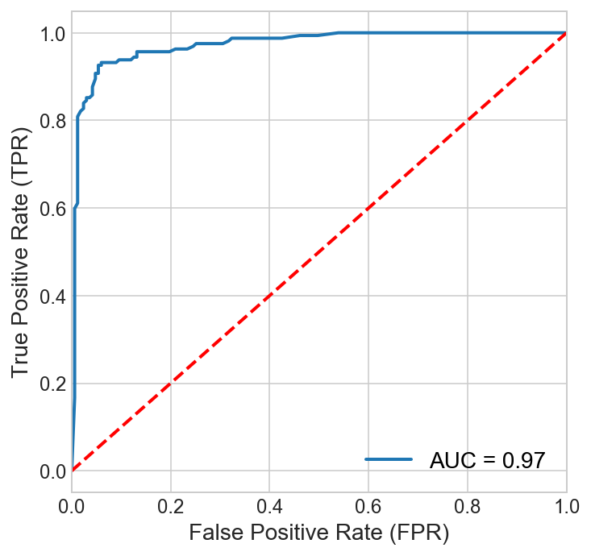

```python
rfc = RandomForestClassifier()
_ = rfc.fit(X_train, y_train)
Performance_rfc = Performance(rfc, X_test)
ROC_rfc = ROC_Curve(rfc, X_test)
```

```python
Best_Features = Feature_Ranking(rfc)
print(Back.BLACK + Fore.CYAN + Style.NORMAL + 'Best Features:')
print(Style.RESET_ALL)
print('%s' % ', '.join(Best_Features))
```

|  | Number of Features to Select | Score | Features | Best Features |
| --- | --- | --- | --- | --- |
| 0 | 2 | 0.850000 | ['Air Pressure', 'Relative Humidity (Morning)'] | ['Air Pressure', 'Relative Humidity (Morning)'] |
| 1 | 3 | 0.910000 | ['Air Pressure', 'Max Wind Direction', 'Relative Humidity (Morning)'] | ['Air Pressure', 'Max Wind Direction', 'Relative Humidity (Morning)'] |
| 2 | 4 | 0.900000 | ['Air Pressure', 'Air Temperature', 'Max Wind Direction', 'Relative Humidity (Morning)'] | ['Air Pressure', 'Air Temperature', 'Max Wind Direction', 'Relative Humidity (Morning)'] |
| 3 | 5 | 0.910000 | ['Air Pressure', 'Air Temperature', 'Avg Wind Direction', 'Max Wind Direction', 'Relative Humidity (Morning)'] | ['Air Pressure', 'Air Temperature', 'Avg Wind Direction', 'Max Wind Direction', 'Relative Humidity (Morning)'] |
| 4 | 6 | 0.920000 | ['Air Pressure', 'Air Temperature', 'Avg Wind Direction', 'Max Wind Direction', 'Max Wind Speed', 'Relative Humidity (Morning)'] | ['Air Pressure', 'Air Temperature', 'Avg Wind Direction', 'Max Wind Direction', 'Max Wind Speed', 'Relative Humidity (Morning)'] |
| 5 | 7 | 0.910000 | ['Air Pressure', 'Air Temperature', 'Avg Wind Direction', 'Avg Wind Speed', 'Max Wind Direction', 'Max Wind Speed', 'Relative Humidity (Morning)'] | ['Air Pressure', 'Air Temperature', 'Avg Wind Direction', 'Avg Wind Speed', 'Max Wind Direction', 'Max Wind Speed', 'Relative Humidity (Morning)'] |
| 6 | 8 | 0.910000 | ['Air Pressure', 'Air Temperature', 'Avg Wind Direction', 'Avg Wind Speed', 'Max Wind Direction', 'Max Wind Speed', 'Rain Duration', 'Relative Humidity (Morning)'] | ['Air Pressure', 'Air Temperature', 'Avg Wind Direction', 'Avg Wind Speed', 'Max Wind Direction', 'Max Wind Speed', 'Rain Duration', 'Relative Humidity (Morning)'] |

```
Best Features:

Air Pressure, Air Temperature, Avg Wind Direction, Max Wind Direction, Max Wind Speed, Relative Humidity (Morning)
```

| Classifier | F1 Score | Precision Score | Recall Score | Score |
| --- | --- | --- | --- | --- |
| Random Forest Classifier | 0.90 | 0.90 | 0.90 | 0.90 |

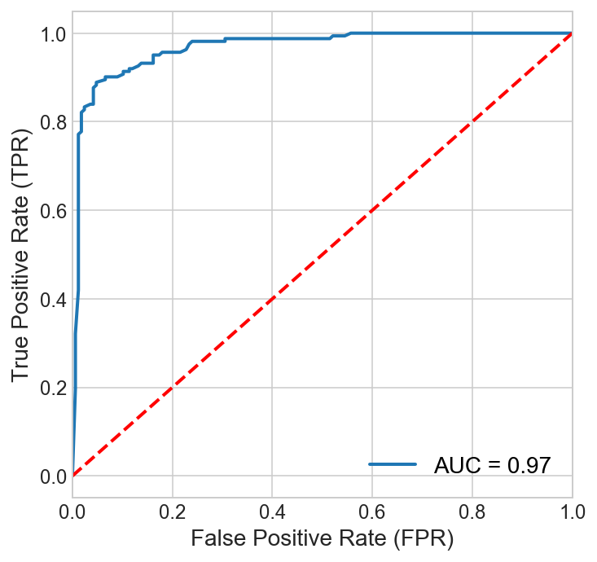

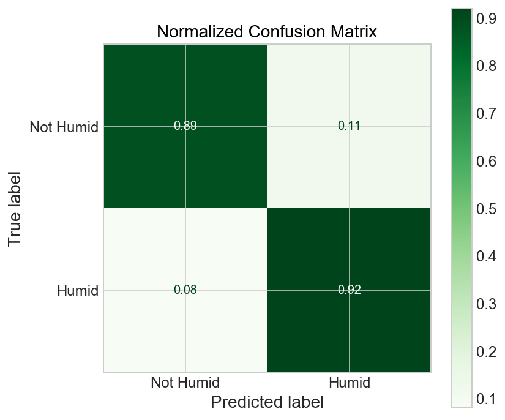

```python
rfc = RandomForestClassifier()
_ = rfc.fit(X_train[Best_Features], y_train)
Performance_rfc = Performance(rfc, X_test[Best_Features])
ROC_rfc = ROC_Curve(rfc, X_test[Best_Features])


fig, ax = plt.subplots(1, 1, figsize=(6, 6))
_ = plot_confusion_matrix(rfc, X_test[Best_Features], y_test, display_labels= ['Not Humid','Humid'],
                      cmap= "Greens", normalize= 'true', ax = ax)
_ = ax.set_title('Normalized Confusion Matrix')
```

# Final Thoughts

```python
pd.concat([Performance_dtc, Performance_rfc], ignore_index=True).style.hide_index().\
                                                                    background_gradient(cmap='Greens').set_precision(2)
```

| Classifier | F1 Score | Precision Score | Recall Score | Score |
| --- | --- | --- | --- | --- |
| Decision Tree Classifier | 0.87 | 0.87 | 0.87 | 0.87 |
| Random Forest Classifier | 0.90 | 0.90 | 0.90 | 0.90 |

```python
fig = go.Figure()
fig.add_trace(go.Scatter(x= ROC_dtc['false positive rates'].values, y= ROC_dtc['true positive rates'].values,
                         line=dict(color='Blue', width= 1.5),
                         name = '<b>Decision Tree</b>'))
fig.add_trace(go.Scatter(x= ROC_rfc['false positive rates'].values, y= ROC_rfc['true positive rates'].values,
                         line=dict(color='Green', width= 1.5),
                         name = '<b>Random Forest</b>'))
fig.add_trace(go.Scatter(x= [0,1], y= [0,1], showlegend = False, line=dict(color='black', width=2, dash='dot')))
fig.update_layout(legend_title='Classifiers')
fig.update_layout(legend=dict(y=0.5, traceorder='reversed', font_size=12))
fig.update_layout(title='ROC, Curves', dragmode='select', plot_bgcolor= 'white',
                  width=610, height=500, hovermode='closest')
fig.update_xaxes(showgrid=True, gridwidth=1, gridcolor='Lightgray')
fig.update_yaxes(showgrid=True, gridwidth=1, gridcolor='Lightgray')
fig.update_xaxes(showline=True, linewidth=1, linecolor='Lightgray', mirror=True)
fig.update_yaxes(showline=True, linewidth=1, linecolor='Lightgray', mirror=True)
fig.show()
```

[interactive chart not shown]

We can see the area under the curve for **Random Forest Classifier** is better, therefore, this classifier performs the best here.